# STAT 578 - Fall 2019 - Assignment 4

Frederick (Eric) Ellwanger - fre2

November 1, 2019

```r
ozone = read.table("ozoneAQIaug.txt", header = TRUE)
```

```r
library(rjags)

d1 <- list(logozone = log(ozone[,c(1:31)]), day = c(1:31), mubeta0 = c(0, 0),
           Sigmamubetainv = rbind(c(0.000001, 0), c(0, 0.000001)),
           Sigma0 = rbind(c(100, 0), c(0, 0.1)))

#Set overdispersed starting points
inits1 <- list(list(sigmasqyinv = 10, mubeta = c(1000, 1000),
                    Sigmabetainv = rbind(c(100, 0), c(0, 100))),
               list(sigmasqyinv = 0.001, mubeta = c(-1000, 1000),
                    Sigmabetainv = rbind(c(100, 0), c(0, 100))),
               list(sigmasqyinv = 10, mubeta = c(1000, -1000),
                    Sigmabetainv = rbind(c(0.001, 0), c(0, 0.001))),
               list(sigmasqyinv = 0.001, mubeta = c(-1000, -1000),
                    Sigmabetainv = rbind(c(0.001, 0),c(0, 0.001))))

#Setup model
m1 <- jags.model("ozone1.bug", d1, inits1, n.chains=4, n.adapt=2000)
```

```
## Compiling data graph
##    Initializing
##    Reading data back into data table
##
```

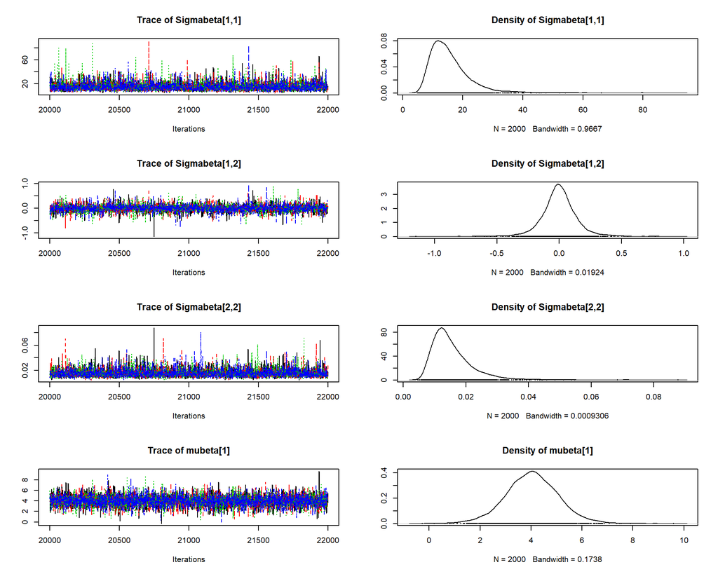

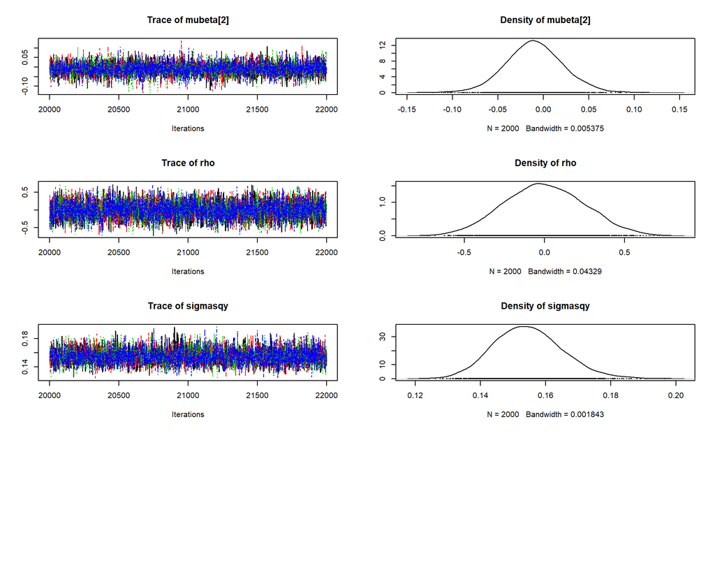

```r
#Burn-in
update(m1, 20000)

#Run model
x1 <- coda.samples(m1, c("mubeta[1]","mubeta[2]","Sigmabeta[1,1]","Sigmabeta[1,2]",
                   "Sigmabeta[2,2]","sigmasqy","rho"), n.iter=2000)

#Check for convergence
plot(x1, smooth = FALSE)
```

```r
#Another check for convergence
gelman.diag(x1, autoburnin=FALSE, multivariate=FALSE)
```

```
## Potential scale reduction factors:
##
##                Point est. Upper C.I.
## Sigmabeta[1,1]          1       1.01
## Sigmabeta[1,2]          1       1.00
## Sigmabeta[2,2]          1       1.00
## mubeta[1]               1       1.00
## mubeta[2]               1       1.00
## rho                     1       1.00
## sigmasqy                1       1.00
```

```r
#Another check for convergence and Neff > 4000/parameter
effectiveSize(x1[,c("mubeta[1]","mubeta[2]","Sigmabeta[1,1]","Sigmabeta[1,2]",
                    "Sigmabeta[2,2]","sigmasqy","rho")])
```

```
##      mubeta[1]      mubeta[2] Sigmabeta[1,1] Sigmabeta[1,2] Sigmabeta[2,2]
##           8245           8132           7164           6558           7190
##       sigmasqy            rho
##           6916           6773
```

**There does not appear to be any issues with convergance and all monitored parameters exceed an effective sample size of 4000**

**(b)(ii) Display the coda summary of the results for the monitored parameters.**

```r
(x1sum = summary(x1))
```

```
##
## Iterations = 20001:22000
## Thinning interval = 1
## Number of chains = 4
## Sample size per chain = 2000
##
## 1. Empirical mean and standard deviation for each variable,
##    plus standard error of the mean:
##
##                     Mean      SD  Naive SE Time-series SE
## Sigmabeta[1,1] 15.606520 6.78787 0.0758907      0.0803931
## Sigmabeta[1,2] -0.000379 0.13997 0.0015649      0.0017331
## Sigmabeta[2,2]  0.015461 0.00658 0.0000735      0.0000779
## mubeta[1]       4.035136 1.02241 0.0114309      0.0112780
## mubeta[2]      -0.009914 0.03193 0.0003570      0.0003542
## rho            -0.001274 0.24646 0.0027555      0.0030006
## sigmasqy        0.154631 0.01049 0.0001173      0.0001266
##
## 2. Quantiles for each variable:
##
##                   2.5%     25%      50%     75%   97.5%
## Sigmabeta[1,1]  7.2917 11.0331 14.19821 18.4071 32.5799
## Sigmabeta[1,2] -0.2806 -0.0747 -0.00217  0.0721  0.2942
## Sigmabeta[2,2]  0.0073  0.0111  0.01396  0.0182  0.0318
## mubeta[1]       2.0072  3.3751  4.03100  4.7008  6.0871
## mubeta[2]      -0.0730 -0.0306 -0.01036  0.0104  0.0541
## rho            -0.4748 -0.1739 -0.00538  0.1708  0.4889
## sigmasqy        0.1353  0.1472  0.15415  0.1614  0.1769
```

**(b)(iii) Give an approximate 95% central posterior credible interval for the correlation parameter $\rho$, and also produce a graph of its (estimated) posterior density.**

```r
(rhostats = x1sum$quantiles["rho", c("2.5%", "97.5%")])
```

```
##   2.5%  97.5%
## -0.475  0.489
```

**The 95% central posterior credible interva, for $\rho$ is (-0.475, 0.489)**

**(b)(iv) Approximate the posterior probability that $\rho$ > 0. Also, compute the Bayes factor favoring $\rho$ > 0 versus $\rho$ < 0. (You may use the fact that $\rho$ > 0 and $\rho$ < 0 have equal prior probability.) Describe the level of data evidence that $\rho$ > 0.**

```r
rho.sim = as.matrix(x1)[, 6]
mean(rho.sim > 0)
```

```
## [1] 0.49
```

**The approximate posterior probability that $\rho>0 \approx$ 0.49**

```r
#Since PR_prior_h1 = PR_prior_h2 we divide by 1
(BF = (mean(rho.sim > 0)/(1 - mean(rho.sim > 0)))/1)
```

```
## [1] 0.962
```

**The Bayes Factor is approximately 0.962. This is at a barely mentionable level on the Bayes Factor scale, suggesting there isn’t much evidence to support that $\rho > 0$**

**(b)(v) Your model implies that, over the 30-day period from the first day of August to the last, the (population) median ozone AQI value should have changed by a factor of:**

**$e^{30\mu_{\beta2}}$**

**Form an approximate 95% central posterior credible interval for this quantity.**